# NBA Top 3 Players

This file will explore the comparisons between Lebron James, Michael Jordan, and Kobe Bryant. I have gathered season stats for each of the three players and used the data to analyze their performances.

#### Lebron James-Small Forward

Generally thought of as the most versatile player. Has the ability to dive to the basket and finish strong or with a skillful layup. Has developed and extremely effective post game. Jumpshot is hit-or-miss, with noticable struggles from the free throw line. Extremelly athletic, lockdown defender, and can pass like an elite point guard.

#### Michael Jordan-Shooting Guard

Explosive, high-flying player who can score at will. Great post game paired with a signature fadeway jumpshot. Unmatched athletisicm that he used to for incredible dunks and to blow by defenders. Known for winning 6 NBA championships and and making clutch shots in big games.

#### Kobe Bryant-Shooting Guard

Thought of as the second coming of Jordan. Scoring monster who is always in attack mode. Has deadly jumpshot mixed with elite athletisicm, great defense, and a relentless competitive spirit.

## Analysis

I generated graphs of points per game, rebounds per game, steals per game, blocks per game, field goal percentage, 3 point percentage, and turnovers per game.

Jordan was the most successful scorer, having 2 seasons where he averages 35 PPG or more. This has only been done a few times in the history of the NBA, so the fact that he has done it twice is astounding. He also has the most seasons averaging 30 points or more with 8 seasons, followed by Kobe with 3 and Lebron with 2. His average field goal percentage is just below 50%, proving he was also scoring efficiently. Jordan also has the most steals and blocks, suggesting he was the best defender of the three.

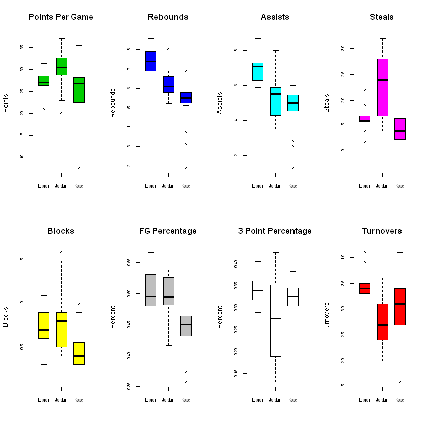

```r
#Creates plot layout
par(mfrow = c(2, 4))

#Generates boxplots of stats
boxplot(lebron$PTS, jordan$PTS, kobe$PTS, main = 'Points Per Game', ylab = 'Points', names = c('Lebron', 'Jordan', 'Kobe'), col = 3, boxwex = 0.6, cex.main = 1.2, cex.axis = 0.6)
boxplot(lebron$TRB, jordan$TRB, kobe$TRB, main = 'Rebounds', ylab = 'Rebounds', names = c('Lebron', 'Jordan', 'Kobe'), col = 4, boxwex = 0.6, cex.main = 1.2, cex.axis = 0.6)
boxplot(lebron$AST, jordan$AST, kobe$AST, main = 'Assists', ylab = 'Assists', names = c('Lebron', 'Jordan', 'Kobe'), col = 5, boxwex = 0.6, cex.main = 1.2, cex.axis = 0.6)
boxplot(lebron$STL, jordan$STL, kobe$STL, main = 'Steals', ylab = 'Steals', names = c('Lebron', 'Jordan', 'Kobe'), col = 6, boxwex = 0.6, cex.main = 1.2, cex.axis = 0.6)

boxplot(lebron$BLK, jordan$BLK, kobe$BLK, main = 'Blocks', ylab = 'Blocks', names = c('Lebron', 'Jordan', 'Kobe'), col = 7, boxwex = 0.6, cex.main = 1.2, cex.axis = 0.6)
boxplot(lebron$FGp, jordan$FGp, kobe$FGp, main = 'FG Percentage', ylab = 'Percent', names = c('Lebron', 'Jordan', 'Kobe'), col = 8, boxwex = 0.6,cex.main = 1.2, cex.axis = 0.6)
boxplot(lebron$X3Pp, jordan$X3p, kobe$X3Pp, main = '3 Point Percentage', ylab = 'Percent', names = c('Lebron', 'Jordan', 'Kobe'), col = 0, boxwex = 0.6, cex.main = 1.2, cex.axis = 0.6)
boxplot(lebron$TOV, jordan$TOV, kobe$TOV, main = 'Turnovers', ylab = 'Turnovers', names = c('Lebron', 'Jordan', 'Kobe'), col = 10, boxwex = 0.6, cex.main = 1.2, cex.axis = 0.6)
```

## Three Point Shooting

I used more data visualization techniques to examine the 3 point shooting. The top row of graphs shows the difference between the 3 point shots attempted versus 3 point shots made. The gap between the red and green lines relates to the 3 point percentage, where a large gap means lower shooting percentage and a small gap means higher shooting percentage. The bottom row of graphs shows 3 point percentage for each season.

Jordan has the lowest few recorded percentages of all of the three. He seriously struggled in his first 3 seasons, unable to average more than 18.2 percent in each. He later improved drastically enough to post the highest percentage of 42.7% in at age 32. This was after he had only played the last 17 games of the prior season, and had been retired for the two seasons before that. I believe that Jordan wasn't only just playing minor league baseball and that he was still working on his jumpshot. In those 17 games he played after his return, he shot and improved 50.0% from the three point line. He then went on to average 33.22% for the next 3 seasons after only averaging 24.58% for his first 7 seasons.

Lebron and Kobe's scatterplot spreads are both very precise. However, one thing I noticed was that Lebron's percentage increases with time, while Kobe's decreases. I believe this is a reflection of the way defenders guard each player. Lebron is know as a "drive first then shoot", so defenders are told to back up off him and force him to hit the open jumpshot. This called an uncontested shot, and is the easiest 3 point shot that can be taken. Kobe is a "shoot first then drive" so defenders will be close to his body, guarding any jumpshot that he will attempt. This forces him to take tough fadeaways, shoot off the dribble, and take contested shots. Since these shots have much higher difficulty, it makes sense that Kobe's percentage is lower even though he is actually a better 3 point shooter.

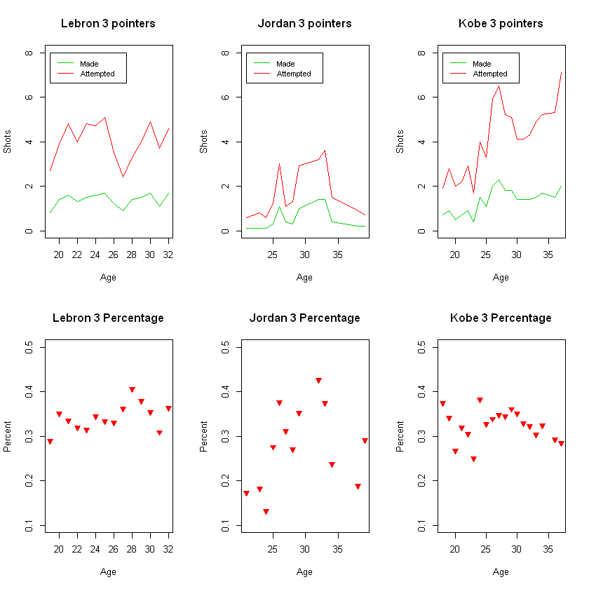

```r
par(mfrow = c(2, 3))

plot(lebron$Age, lebron$X3P, main = 'Lebron 3 pointers', xlab = 'Age', ylab = 'Shots', type = 'l', ylim = c(0, 8), col = 3)
lines(lebron$Age, lebron$X3PA, col = 2)
legend(19, 8, c('Made', 'Attempted'), lty=c(1,1), col=c(3, 2), cex = 0.85)

plot(jordan$Age, jordan$X3P, main = 'Jordan 3 pointers', xlab = 'Age', ylab = 'Shots', type = 'l', ylim = c(0, 8), col = 3)
lines(jordan$Age, jordan$X3PA, col = 2)
legend(21, 8, c('Made', 'Attempted'), lty=c(1,1), col=c(3, 2), cex = 0.85)

plot(kobe$Age, kobe$X3P, main = 'Kobe 3 pointers', xlab = 'Age', ylab = 'Shots', type = 'l', ylim = c(0, 8), col = 3)
lines(kobe$Age, kobe$X3PA, col = 2)
legend(18, 8, c('Made', 'Attempted'), lty=c(1,1), col=c(3, 2), cex = 0.85)

plot(lebron$Age, lebron$X3Pp, pch = 25, col = 2, bg = 2, main = 'Lebron 3 Percentage', xlab = 'Age', ylab = 'Percent', ylim = c(0.1, 0.5))
plot(jordan$Age, jordan$X3p, pch = 25, col = 2, bg = 2, main = 'Jordan 3 Percentage', xlab = 'Age', ylab = 'Percent', ylim = c(0.1, 0.5))
plot(kobe$Age, kobe$X3Pp, pch = 25, col = 2, bg = 2, main = 'Kobe 3 Percentage', xlab = 'Age', ylab = 'Percent', ylim = c(0.1, 0.5))
```

## Defensive Play

All three players are all-time great defenders. Kobe and Jordan have been named to the NBA All-Defensive 1st Team 9 times, and Lebron has been named 5 times. To analyze the defensive abilities of each player, I generated more indepth graphs of steals and blocks.

Jordan clearly dominates in steals, averaging 2.34 steals per game to Lebron's 1.65 and Kobe's 1.41. This is a surprising difference, considering all three are elite defenders. I believe his ability to create turnovers stems from his high basketball IQ. He is able to read players well enough to predict their next move and steal the ball. Lebron and Kobe's steals per game are also very high, so Jordan averaging almost a steal more than both of them is impressive.

As far as blocks, you would think Lebron would win this one because he is more of a low-post player who can block many shots with his supreme athletisicm. Surprisingly, Jordan also wins this category. As a shooting guard, it is very uncommon to have anywhere near 1.5 blocks per game. Jordan has done this twice in his career. However, his average gradually decreases after those two years. This could be due to improved team defense from the play of Scottie Pippen and Dennis Rodman. With improved team defense, Jordan would not have to be as prevalent on defense so that hes could focus on offense. This is backed by his increase in points per game, 3 point percentage, and field goal percentage in the next few seasons.

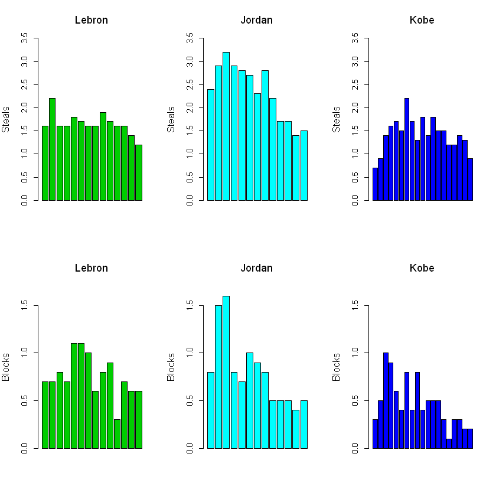

```r
par(mfrow = c(2, 3))

barplot(lebron$STL, main = "Lebron", cex.main = 1.4, font.main = 1, xlab = '', ylab = 'Steals', cex.lab = 1.2, ylim = c(0, 3.5), col = 3)
barplot(jordan$STL, main = "Jordan", cex.main = 1.4, font.main = 1, xlab = '', ylab = 'Steals', cex.lab = 1.2, ylim = c(0, 3.5), col = 5)
barplot(kobe$STL, main = "Kobe", cex.main = 1.4, font.main = 1, xlab = '', ylab = 'Steals', cex.lab = 1.2, ylim = c(0, 3.5), col = 4)

barplot(lebron$BLK, main = "Lebron", cex.main = 1.4, font.main = 1, xlab = '', ylab = 'Blocks', cex.lab = 1.2, ylim = c(0, 1.7), col = 3)
barplot(jordan$BLK, main = "Jordan", cex.main = 1.4, font.main = 1, xlab = '', ylab = 'Blocks', cex.lab = 1.2, ylim = c(0, 1.7), col = 5)
barplot(kobe$BLK, main = "Kobe", cex.main = 1.4, font.main = 1, xlab = '', ylab = 'Blocks', cex.lab = 1.2, ylim = c(0, 1.7), col = 4)
```

## Conclusion

Lebron is the best player out of the three. He is able to use his size, strength, and athletisicm to score the basketball in a variety of ways. Defenders must also be weary that he can post double-digit assists on any given night. He can rebound the basketball much better than Jordan or Kobe. On the defensive end, Lebron still has great numbers for steals and blocks. Unlike the others, he is versatile enough to guard all five positions successfully.